# Kusama Auctions 6-11: Report (WIP)

Jonas Gehrlein

14/10/2021

## Auction Schedule

The second batch of auctions was enabled by the governance body of the Kusama network and it was initially planned to allocate another set of five parachain slots. Later and after some discussion within the community, the council, as representatives of the token holders, scheduled a sixth auction. This brings the total number of parachains as the time of writing to twelve (eleven allocated by auctions and *Statemine* as public good chain by governance). This was possible because experts agreed on the technical stability of the network and that the additional auction would fit the duration of the current crowdloans. In total, the whole campaign went on from September 01st until October 13th. Each auction lasted seven days with a two-day starting and five-day candle phase. The following table provides the dates for the four important events of each auction (the same table with the events expressed in their block heights can be found in the Appendix).

|  | Start | End | Start of Candle Period | Date of Termination Block |
| --- | --- | --- | --- | --- |
| Auction 6 | 01.09.2021 | 08.09.2021 | 03.09.2021 | 05.09.2021 |
| Auction 7 | 08.09.2021 | 15.09.2021 | 10.09.2021 | 10.09.2021 |
| Auction 8 | 15.09.2021 | 22.09.2021 | 17.09.2021 | 20.09.2021 |
| Auction 9 | 22.09.2021 | 29.09.2021 | 24.09.2021 | 25.09.2021 |
| Auction 10 | 29.09.2021 | 06.10.2021 | 01.10.2021 | 01.10.2021 |
| Auction 11 | 06.10.2021 | 13.10.2021 | 08.10.2021 | 10.10.2021 |

## Overview

The following table summarizes relevant metrics for the seven projects with the highest locked KSM for crowdloans ordered by the amount of contributions (the full table is available in the Appendix)).

|  | Number Contributors | Unique Contributors | Sum of Contributions (in KSM) | Average Contribution (in KSM) |
| --- | --- | --- | --- | --- |
| Basilisk | 18560 | 11891 | 222221.9 | 12.0 |
| KILT Spiritnet | 12212 | 7997 | 219999.9 | 18.0 |
| Calamari | 19764 | 16005 | 218246.6 | 11.0 |
| Parallel Heiko | 12606 | 10472 | 202793.4 | 16.1 |
| Kintsugi BTC | 11826 | 8013 | 199999.9 | 16.9 |
| Altair | 18343 | 11201 | 187835.2 | 10.2 |
| PolkaSmith | 5143 | 3030 | 27342.6 | 5.3 |

The following graph shows the cumulative contributions of the seven highest-backed crowdloans for the whole campaign. This gives some visual insights about the contribution dynamic to the different projects.

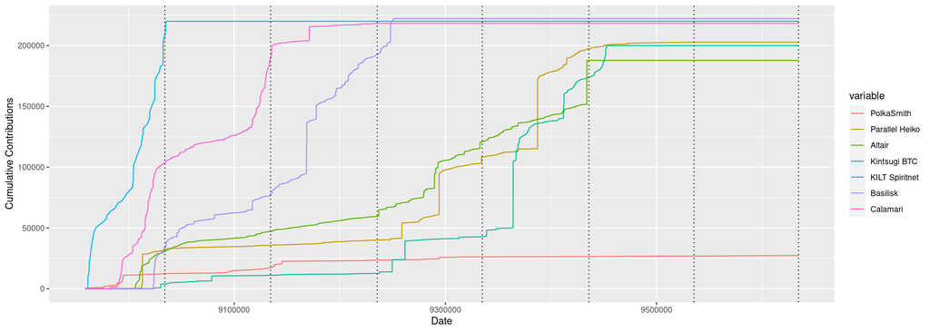

We can spot a clear hierarchy between the contribution levels in the first three auctions, while things get more dynamic especially for the fourth auction. As all bids were made for the same leasing periods (full duration of the slot), contributions can be compared within a single graph. Upon visual inspection of the graph above, we can see that the contribution curve flattens out for several teams. There are two reasons for this. First, after a crowdloan won an auction and second, once a crowdloan reaches it’s cap. In both cases, no further contributions are accepted by the Relay Chain. During the whole campaign, six teams obtained a slot while three of them reached their crowdloan cap before their respective auction ended.

We’ll have a closer look at each auction in the following.

## Auction 6-8

Similarly to the first batch of auctions, we observed three strong teams taking the lead from early on. Those managed to win auction 6-8 without much interference with each other. That means, at no point during the auctions, a winning bid has changed between a team. KILT Spiritnet, the winner of the first auction of this batch, i.e., auction 6, reached their cap of 220’000 KSM shortly after the beginning and well before the candle period started. While the contribution levels of the two other teams came close to each other, at no point did the winning bid change during the respective auctions. That means, the second auction was won by Calamari with a total of 218,247 locked KSM and auction 8 was won by Basilisk after hitting their cap with a total of 222,222 KSM.

The following graph illustrates the dynamics of the crowdloan contributions of those three projects aggregated on a daily basis. The vertical lines correspond to the ending dates of the respective auctions.

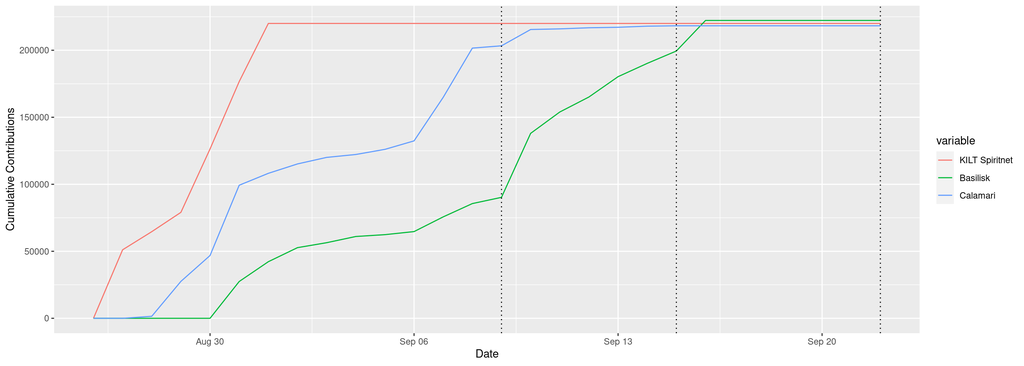

## Auction 9

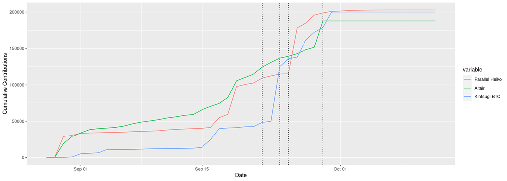

We can see that Altair led the cumulative sum of contributions in the pre-candle phase and some time at the beginning of the decisive candle period. Specifically, they led around 35.2% of the candle phase. Eventually, in block number 9387388, Parallel Heiko’s crowdloan received a single contribution of 57,320 KSM which lead to their crowdloan getting ahead in the auction and securing the winning bid. Eventually, Kintsugi BTC also managed to overtake Altair, putting them in the last place for the ninth auction. Yet, Altair took back the lead over Kintsugi BTC shortly before the end to obtain the second place. At the end of the auction, contributors bonded 187,835.2 KSM for Altair, 196,985.7 KSM for Parallel Heiko and 173,299.2 KSM for Kintsugi BTC. Technically, either Altair or Parallel Heiko could win in this close race. Kintsugi BTC was not eligible to win, because they never obtained a winning bid in the candle period. In the following graph, we increase the resolution to aggregated contributions on a block-level and focus only on the time of the auction itself.

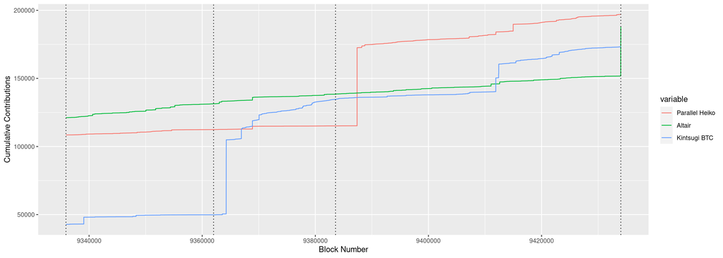

The third vertical line indicates the block that was randomly chosen retrospectively to determine the winner. We can see that the auction terminated shortly before Parallel Heiko could secure the lead, which eventually led to Altair winning the ninth auction and obtained the respective slot.

## Who blows out the candle?

To answer this question, we need to learn some more details about how bids are stored in the first place. This is achieved with a technique called *sampling*. The candle period lasts exactly 72’000 blocks and is divided into 3600 samples (i.e., every 20 blocks). Those samples are essentially like any other block, but they also store the current winner(s) of the auction. Compared to the case of storing the information in all blocks, this vastly reduces storage requirements and thereby puts much less load on the blockchain. After the auction concludes, one of those samples is selected with equal probability. Then, the bidders that held the winning bid(s) in this selected block are chosen as winners and they are rewarded with the respective lease periods. As all samples have an equal probability to be selected and there are a sufficient number of samples, auctions should end, on average, at 50% of their candle period (later more on this).

In auction 9, this happened in block 9434278 at event with index 0 (LINK https://kusama.subscan.io/extrinsic/9434278-0?event=9434278-0). The parent block updated the epoch randomness and thereby provided the needed input to determine the winning sample, a parameter called the *winningOffset*. That number, in this case 1078, dedicates the sample that has been chosen as termination block of the auction. If we take the start block of the candle period, 9362014, and add 1078 * 20 = 21560 blocks to it, we calculated the termination block, 9383574, ourselves.

In conclusion, the validator that produces the block containing the *winningOffset* figuratively blows out the candle. Yet, on a further inspection, it is the aggregated randomness provided by all block-producing validators of the previous epoch that contributed to the final value. Therefore, the validator producing the block 9434278 was merely the messenger of the result and did not have any influence on the outcome.

## Auction 10

Continuing with the lead from Auction 9, Parallel Heiko entered the bidding. With a strong position from the fourth auction, Parallel Heiko continued to compete for the, it seemed, last available slot. The vertical lines indicates the beginning and end of the auction.

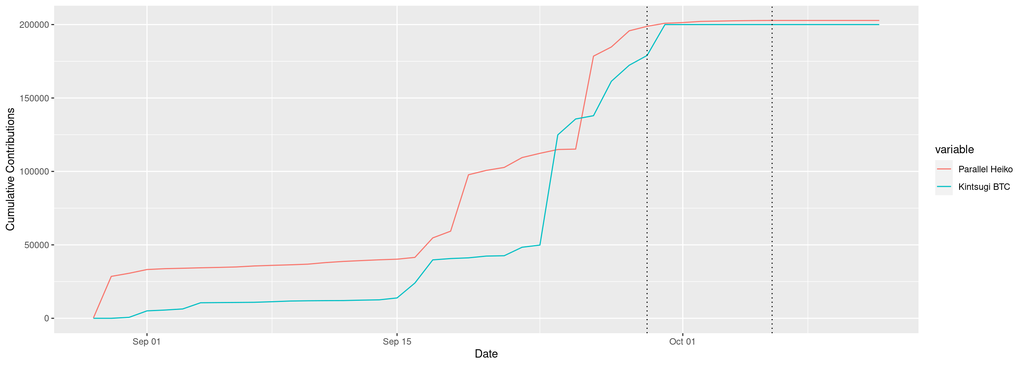

Because Parallel Heiko set a funding cap of 400’000 KSM and Kintsugi BTC of 200’000 KSM, the former was able to outcompete the latter. Parallel Heiko had the winning bid in 100% of the samples, and thus, it was clear that they would win the slot. Kintsugi BTC reached their cap during the auction and therefore was not able to gather more contributions, which sealed the outcome. One could argue, that for the first time on Kusama auctions, the outcome was determined by the contribution cap that was set by a team. Eventually, Parallel Heiko won the auction 10 with 202,793.4 KSM.

# Auction 11: Expected chaos

### The Impact of the Candle Mechanism

The candle auction is composed of two different stages, namely the starting and candle phase. The latter is further divided (retrospectively), into a period that falls before and after the termination block. This mechanism could lead to the situation that the highest bidder at the end of the auction does not necessarily win the auction, because their winning bid is discarded if it falls into the range after the termination block. This occurred during Auction 9. All tokens that are contributed to a winning crowdloan during the whole auction would still be locked for the entirety of the respective leasing period. This means that we could observe some inefficiency, both in determining the winner and in locking tokens that did not contribute to a higher winning bid. In the next table, the sum of contributions is separated by the respective phases. Additionally, the table shows when the termination block occurred as a percent of the whole candle phase.

| Name | Pre-Candle Phase | Candle Phase (Pre-Termination) | Candle Phase (Post-Termination) | Termination Time (in % of Candle Phase) |
| --- | --- | --- | --- | --- |
| KILT Spiritnet | 220’000 KSM | 0 KSM | 0 KSM | 47% |
| Calamari | 203’560 KSM | 504 KSM | 14’183 KSM | 13% |
| Basilisk | 222’222 KSM | 0 KSM | 0 KSM | 53% |
| Altair | 131’372 KSM | 7’030 KSM | 49’433 KSM | 30% |
| Parallel | 201’135 KSM | 142 KSM | 1’517 KSM | 7.6% |
| Kintsugi BTC | 200’000 KSM | 0 KSM | 0 KSM | 46% |

## Comparison between batches

The table below compares the first and the second set of auctions by some key metrics. As we can see, the number of contributions almost doubled, as well as the unique participating accounts.

[output not shown]

The average contributions for winning crowdloans (i.e., the amount of tokens required to be bonded for a slot) was higher in the first round, on average, than in the second round. This is mainly due to the crowdloan by Karura, which received around 501’000 KSM. Given that the second batch of auctions had roughly double the contributions, while locked KSM were similarly, the average contribution per account was roughly half in the current batch.

Examining the average candle expiration, i.e., the percentage at which the candle expired during the candle phase, we observe that the average is smaller in the second batch than in the first. As the VRF produces randomness this is prone to statistical noise. Combining both batches together, auctions terminated on average at 51.09%, which is very close to the theoretical prediction of 50%.

## Summary

First, we saw for the first time ever on any Kusama auction, that the candle mechanism picked a winner that was not in the lead at the end of the auction. This further emphasizes the importance of contributing as early as possible during the candle period, both for users as well as teams that might help their own crowdloan.

Third, we saw the governance body of Kusama react quickly and flexibly to new circumstances enabling another auction. This was possible, because of active discussions in the community and technical experts evaluating the stability of the network. Given an eleventh auction fit the crowdloan contributions, it was possible that already made contributions could be used in the auction. Eventually, the number of parachain slots on Kusama increased to twelve.

# Appendix

## Events of auctions expressed in block heights

|  | Start | End | Start Candle Period | Termination Block |
| --- | --- | --- | --- | --- |
| Auction 6 | 9034309 | 9133371 | 9061309 | 9095449 |
| Auction 7 | 9134492 | 9233727 | 9161492 | 9170992 |
| Auction 8 | 9235576 | 9334719 | 9262576 | 9301076 |
| Auction 9 | 9335014 | 9434014 | 9362014 | 9383574 |
| Auction 10 | 9435968 | 9534968 | 9462968 | 9468468 |
| Auction 11 | 9535569 | 9634569 | 9562569 | 9595549 |

## Full table of crowdloans

|  | Number Contributors | Unique Contributors | Sum of Contributions | Average Contribution |
| --- | --- | --- | --- | --- |
| Basilisk | 18560 | 11891 | 222222 | 12.0 |
| KILT Spiritnet | 12212 | 7996 | 220000 | 18.0 |
| Calamari | 19764 | 16003 | 218247 | 11.0 |
| Parallel Heiko | 12606 | 10472 | 202793 | 16.1 |
| Kintsugi BTC | 11826 | 8012 | 200000 | 16.9 |
| Altair | 18343 | 11201 | 187835 | 10.2 |
| PolkaSmith | 5143 | 3030 | 27343 | 5.3 |
| Picasso | 1318 | 1157 | 17167 | 13.0 |
| Genshiro | 4814 | 2775 | 17036 | 3.5 |
| Integritee Network | 4570 | 3817 | 13192 | 2.9 |
| SherpaX | 1159 | 893 | 7596 | 6.6 |
| Robonomics | 1899 | 1106 | 6184 | 3.3 |
| Sakura | 2231 | 987 | 4747 | 2.1 |
| Crust Shadow | 1003 | 439 | 2995 | 3.0 |
| SubGame Gamma | 312 | 301 | 663 | 2.1 |
| Mars | 231 | 221 | 570 | 2.5 |